# Домашняя работа №1

Роман Меняльщиков

11 10 2020

### Нормирование

#### Гипотеза:

Показатели географических явлений измеряются в различных единицах и имеют совершенно разную размерность и разброс. Например, валовой сбор сельскохозяйственных культур измеряется в тоннах, посевная площадь – в гектарах. Иногда требуется сравнить показатели между собой, их неравномерность и разброс, но разные единицы не позволяют это сделать. Чтобы избежать данной проблемы используется стандартизация или нормирование.

#### Методика:

Где $x_i$ – исходное значение признака, $\bar{x}$, $\delta_x$ – среднее значение и стандартное отклонение признака, рассчитанные по исходному набору данных, $z_i$ - это мера относительного разброса наблюдаемого или измеренного значения, которая показывает, сколько стандартных отклонений составляет его разброс относительного среднего значения.

Кроме этого, стандартизацию можно проводить с помощью линейного масштабирования:

$$X_{lm} = \frac{x_i-x_{min}}{x_{max}-x_{min}}$$

В результате этой трансформации значение приводится к единому диапазону значение [0;1].

#### Эмпирика:

В работе используются данные о посевной площади (га) сахарной свеклы и сахарного тростника стран мира, валовом сборе (т), урожайности (т/га), а также ВВП (долл.), численности населения (чел.) и площадь сельскохозяйственных земель (км2). Вся информация взята с [FAOSTAT](http://www.fao.org/faostat/en/#home) и [World Bank](https://data.worldbank.org/). Расчеты произведены с помощью R Studio.

#### Результаты:

На основе имеющихся данных рассчитаны описательные статистики для обычных и стандартизированных показателей.

1. **Численность населения:**

```
     Min.   1st Qu.    Median      Mean   3rd Qu.      Max.      NA's
1.122e+04 1.602e+06 9.923e+06 2.995e+08 5.463e+07 7.424e+09         1
```

Стандартизированный вариант

```
       V1
 Min.   :-0.3162
 1st Qu.:-0.3145
 Median :-0.3057
 Mean   : 0.0000
 3rd Qu.:-0.2585
 Max.   : 7.5208
 NA's   :1
```

2. **ВВП:**

```
     Min.   1st Qu.    Median      Mean   3rd Qu.      Max.      NA's
3.655e+07 8.734e+09 5.160e+10 2.515e+12 5.157e+11 7.634e+13        15
```

Стандартизированный вариант:

```
       V1
 Min.   :-0.2979
 1st Qu.:-0.2968
 Median :-0.2918
 Mean   : 0.0000
 3rd Qu.:-0.2368
 Max.   : 8.7435
 NA's   :15
```

3. **Площадь сельскохозяйственных земель:**

```
    Min.  1st Qu.   Median     Mean  3rd Qu.     Max.     NA's
       3     5868    53690  1979416   457500 48632688        8
```

Стандартизированный вариант:

```
       V1
 Min.   :-0.3426
 1st Qu.:-0.3416
 Median :-0.3333
 Mean   : 0.0000
 3rd Qu.:-0.2634
 Max.   : 8.0740
 NA's   :8
```

4. **Площадь посевов сахарной свеклы:**

```
   Min. 1st Qu.  Median    Mean 3rd Qu.    Max.    NA's
     34    3547   18962   88169   64760 1105339      12
```

Стандартизированный вариант:

```
       V1
 Min.   :-0.4896
 1st Qu.:-0.4701
 Median :-0.3844
 Mean   : 0.0000
 3rd Qu.:-0.1300
 Max.   : 5.6502
 NA's   :12
```

5. **Площадь посевов сахарного тростника:**

```
    Min.  1st Qu.   Median     Mean  3rd Qu.     Max.     NA's
       1     4740    26930   266200    93449 10042199       10
```

Стандартизированный вариант:

```
       V1
 Min.   :-0.2413
 1st Qu.:-0.2370
 Median :-0.2169
 Mean   : 0.0000
 3rd Qu.:-0.1566
 Max.   : 8.8627
 NA's   :10
```

6. **Валовой сбор сахарной свеклы:**

```
    Min.  1st Qu.   Median     Mean  3rd Qu.     Max.     NA's
     688    73742   959960  5124356  4830092 42065957       13
```

Стандартизированный вариант:

```
       V1
 Min.   :-0.54338
 1st Qu.:-0.53563
 Median :-0.44164
 Mean   : 0.00000
 3rd Qu.:-0.03121
 Max.   : 3.91773
 NA's   :13
```

7. **Валовой сбор сахарного тростника:**

```
     Min.   1st Qu.    Median      Mean   3rd Qu.      Max.      NA's
       12    171954   1448984  19382150   5967056 746828157        10
```

Стандартизированный вариант:

```
       V1
 Min.   :-0.2332
 1st Qu.:-0.2312
 Median :-0.2158
 Mean   : 0.0000
 3rd Qu.:-0.1614
 Max.   : 8.7540
 NA's   :10
```

8. **Урожайность сахарной свеклы:**

```
   Min. 1st Qu.  Median    Mean 3rd Qu.    Max.    NA's
  6.198  32.218  55.546  49.480  62.450 109.565      13
```

Стандартизированный вариант:

```
       V1
 Min.   :-2.0036
 1st Qu.:-0.7991
 Median : 0.2808
 Mean   : 0.0000
 3rd Qu.: 0.6004
 Max.   : 2.7814
 NA's   :13
```

```
    Min.  1st Qu.   Median     Mean  3rd Qu.     Max.     NA's
  0.9375  38.0122  59.3500  57.4207  75.6452 121.8343       10
```

Стандартизированный вариант:

```
       V1
 Min.   :-2.03784
 1st Qu.:-0.70023
 Median : 0.06961
 Mean   : 0.00000
 3rd Qu.: 0.65752
 Max.   : 2.32396
 NA's   :10
```

#### Верификация

В результате работы были составлены дескриптивные статистики для выбранных показателей в натуральном выражении, было проведено их нормирование и повторный расчет описательных статистик. В результате мы получили величины, которые имеют распределение с параметрами: $\bar{x}$ = 0,$\delta_x$ = 1.

Работа со стандартизованными показателями позволяет сравнивать величины, которые имеют натуральное выражение, между собой, так как нормирование подразумевает меру разброса (в $\delta$) относительно среднего значения. Однако стандартизированная величина не позволяет увидеть исходного распределения и толковать полученные значения с точки реальных величин.

Для дальнейшего исследования отобраны следующие показатели:

1. Площадь посевов (га)
2. Площадь с/х земель (км2)

### Построение кривой Лоренца и расчет индекса неравенства

#### Гипотеза

Среди основных продуцентов сахароносных культур выделяются отдельные группы стран, которые лидируют по посевным площадям сахарной свеклы, либо сахарного тростника. Из-за этого возникает неравномерность и концентрация.

Страны-лидеры по посевным площадям сахарной свеклы сосредоточены в Европе (Россия, Франция, Германия), а сахарного тростника в субтропическом климатическом поясе (Бразилия, Индия). Суммарная доля стран-лидеров в общемировом показателе составляют более 50%.

Для оценки неравномерности построим кривые Лоренца и рассчитаем индекс Джини

#### Методика

*Кривая Лоренца* – это альтернативное графическое представление функции распределения. Непосредственно кривая отображает кумулятивные доли изучаемого показателя. Она отклоняется от линии равномерного распределения или абсолютного равенства.

*Коэффициент Джини* - статистический показатель степени расслоения совокупности по какому-либо изучаемому признаку. Используется для оценки неравенства. Рассчитать коэффициент можно как отношение площади фигуры, образованной кривой Лоренца и прямой равенства, к площади треугольника, образованного прямой равенства и осями.

Кроме этого, существуют и другие индексы концентрации и неравномерности:

1. Коэффициент локализации и концентрации
2. Индекс Хирфиндаля-Хиршмана
3. Коэффициент Лоренца
4. Индекс Тейла

#### Эмпирика

Для расчетов исходные данные по посевной площади были нормированы на общую площадь сельскохозяйственных земель.

#### Результаты

Построим кривую Лоренца для посвеных площадей сахарной свеклы и сахарного тростника, которые нормированы на общую площадь сельскохозяйственных земель

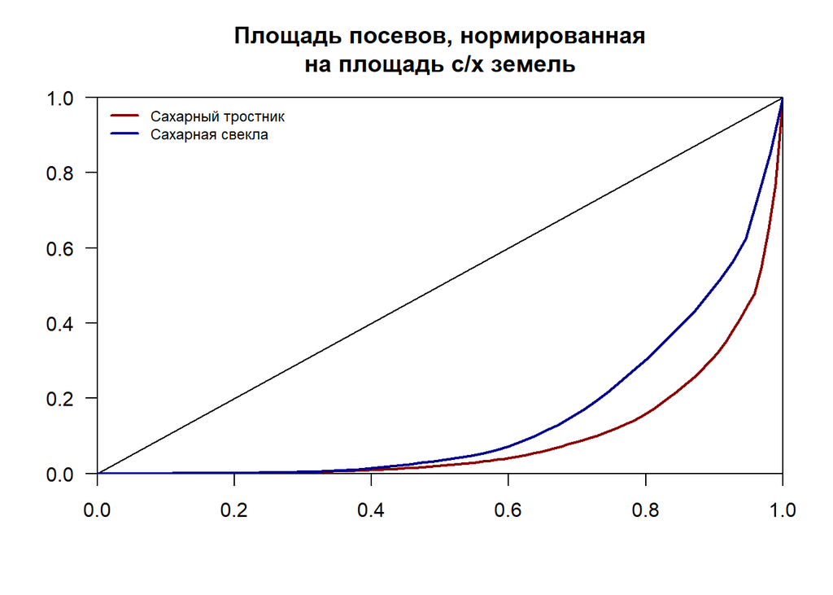

Индекс Джини для посевных площадей сахарной свеклы составляет 0.7, а для сахарного тростника - 0.81. Видно, что концентрация посевных площадей высокая у обоих культур, но у сахарного тростника она выше.

Построим кривую Лоренца для посевных площадей сахараносных культур в целом, которые опять же нормированы на общую площадь сельскохозяйственных земель

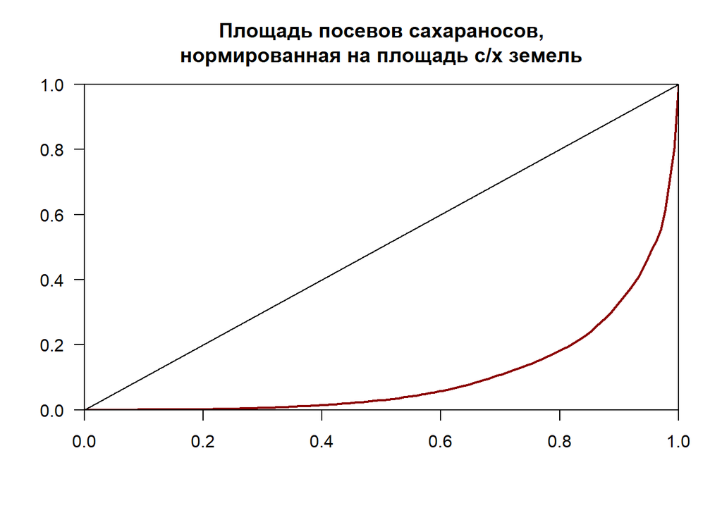

В этом случае иднес Джини равен 0.79. Полученное значение близко к единице, что говорит о неравномерности и концетрации посевных площадей сахарносных культур в небольшом количестве стран.

Кроме этого были построены кривые Лоренца для невзвешенных показателей: площадь посевов и валовой сбор

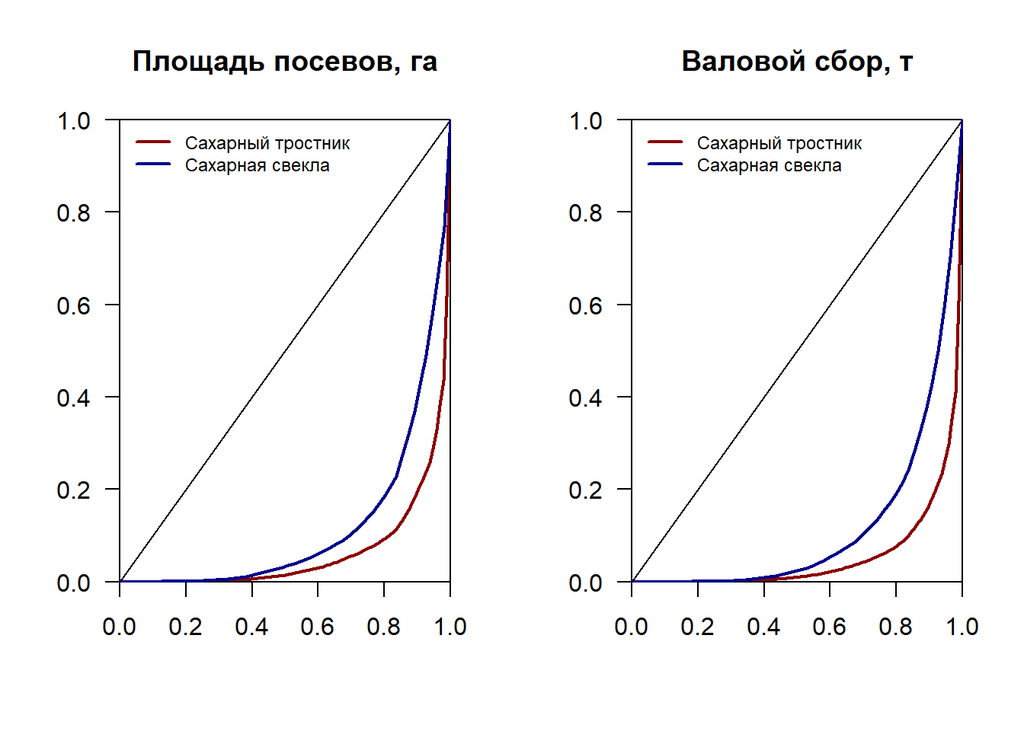

#### Верификация

В результате проведенных расчетов и построений можно сделать вывод о том, что распределение посевных площадей сахарносных культур неравномерно,так как индекци Джини близок к единице, а кривая Лоренца сильно выгнута. Наша гипотеза подтвердилась.

Сахарная свекла и сахарный тростник - культуры, которые требовательны к факторам жизнедеятельности растений, в частности - климату, почвам и количеству влаги. Одновременно эти культуры почти не выращиваются в больших масштабах. Поэтому поэтому почта вся мировая площадь посевов этих сахараносных культур сосредоточена в небольшом количестве стран-лидеров.